# KRM - Benchmark

Now we can have a look at the shape:

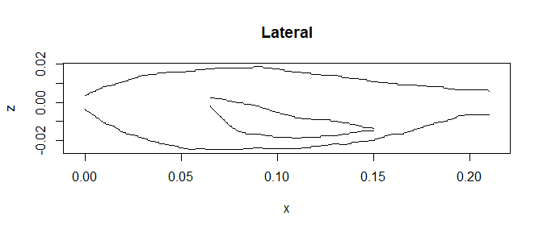

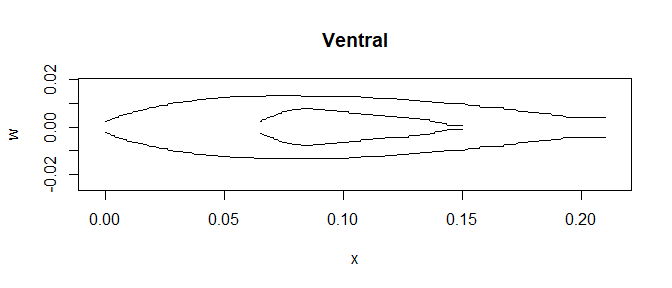

```r
shplot(x_fb = fb$x_fb, w_fb = fb$w_fb, x_sb = sb$x_sb, w_sb = sb$w_sb,z_fbU = fb$z_fbU,z_fbL = fb$z_fbL,z_sbU = sb$z_sbU,z_sbL = sb$z_sbL)
```

Because we have defined the fishbody coordinates and the swimbladder coordinates in a dataframe, the most simple way to run one KRM simulation in KRMr is:

```r
krm(fbshape = fb, sbshape = sb)
```

```
#>   frequency       TS  c_w rho_w theta c_fb c_sb rho_sb rho_fb    L
#> 1    120000 -76.0749 1490  1030    90 1570  345   1.24   1070 0.21
```

```r
TS = krm.sim(frequency =seq(20,200.1) * 1000,
         c.w = 1490,
         rho.w = 1030,
         theta=90,
         c.fb = 1570,
         c.sb = 345,
         rho.sb = 1.24,
         rho.fb = 1070,
         L=0.21,
         x_fb = fb$x_fb,
         x_sb = sb$x_sb,
         w_fb = fb$w_fb,
         w_sb = sb$w_sb,
         z_fbU = fb$z_fbU,
         z_fbL = fb$z_fbL,
         z_sbU = sb$z_sbU,
         z_sbL = sb$z_sbL)
```

Plot the results:

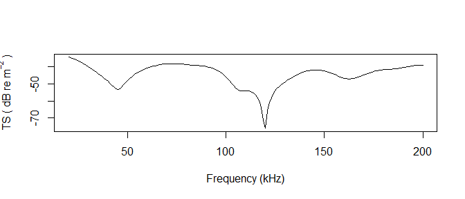

```r
plot(TS$frequency/1000,
     TS$TS,
     type='l',
     xlab='Frequency (kHz)',
     ylab=expression(TS~'('~dB~re~ m^-2~')'))
```

We can also run a simulation over multiple parameters, for example frequencies from 120-200 kHz and incident angles from 65-115 degrees:

```r
TS = krm.sim(frequency =seq(120,200.1) * 1000,
         c.w = 1490,
         rho.w = 1030,
         theta=65:115,
         c.fb = 1570,
         c.sb = 345,
         rho.sb = 1.24,
         rho.fb = 1070,
         L=0.21,
         x_fb = fb$x_fb,
         x_sb = sb$x_sb,
         w_fb = fb$w_fb,
         w_sb = sb$w_sb,
         z_fbU = fb$z_fbU,
         z_fbL = fb$z_fbL,
         z_sbU = sb$z_sbU,
         z_sbL = sb$z_sbL)
```

We can for example use ggplot2 to plot a 2D map of the results:

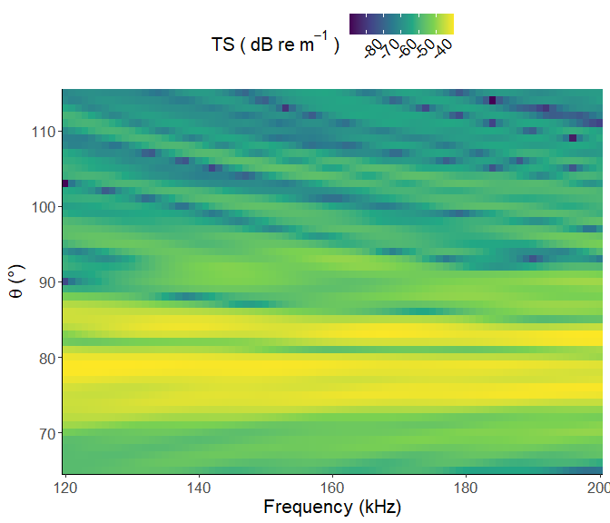

```r
ggplot2::ggplot(data=TS, ggplot2::aes(x= frequency/1000, y= theta, fill=TS))+
  ggplot2::geom_tile()+
  ggplot2::scale_fill_viridis_c(expression(TS~'('~dB~re~ m^-1~')'))+
  ggplot2::xlab('Frequency (kHz)')+
  ggplot2::ylab(expression(theta~'(°)'))+
  ggplot2::scale_x_continuous(expand=c(0,0))+
  ggplot2::scale_y_continuous(expand=c(0,0))+
  ggplot2::theme_classic()+
  ggplot2::theme(legend.position='top',
        legend.text=element_text(angle=45),
        text=element_text(size=16))
```